# Администрирование локальных сетей

Конфигурирование VLAN (Лабораторная работа №5)

Суннатилло Махмудов

07 марта 2026

# Цели и задачи работы

## Цель лабораторной работы

- Получение навыков настройки **VLAN** на коммутаторах сети
- Изучение настройки **VTP Server** и **VTP Client**
- Настройка **Trunk**-соединений между коммутаторами
- Проверка взаимодействия устройств внутри одного VLAN
- Анализ прохождения **ICMP**-пакета в режиме **Simulation**

# Теоретическая часть

## Что такое VLAN

- **VLAN (Virtual Local Area Network)** — технология логического разделения локальной сети
- Позволяет объединять устройства в отдельные логические сегменты независимо от физического расположения
- Уменьшает широковещательный трафик
- Повышает безопасность и упрощает администрирование

## Типы портов VLAN

- **Access-порт**
  - Принадлежит только одной VLAN
  - Используется для подключения ПК и серверов
- **Trunk-порт**
  - Передаёт трафик нескольких VLAN
  - Используется для связи между коммутаторами
- Для маркировки кадров применяется стандарт **IEEE 802.1Q**

## Протокол VTP

- **VTP (VLAN Trunking Protocol)** — протокол централизованного управления VLAN в сети коммутаторов Cisco
- Основные режимы:
  - **Server** — создание и распространение VLAN
  - **Client** — получение VLAN от сервера
  - **Transparent** — передача VTP-сообщений без синхронизации базы VLAN

# Выполнение лабораторной работы

## Настройка VTP Server на msk-donskaya-sw-1

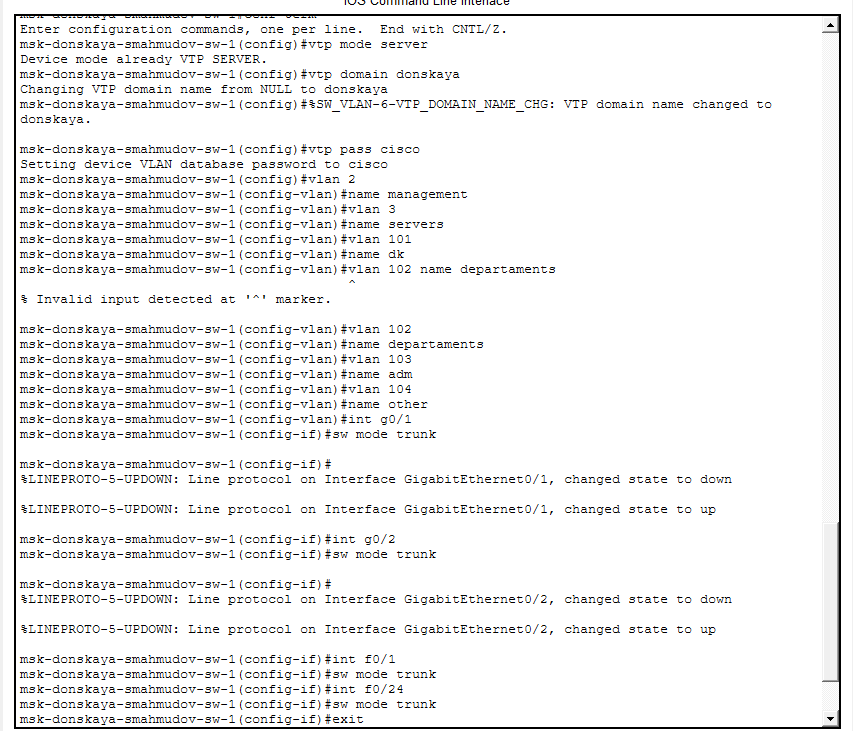

Настройка VTP-сервера, создание VLAN и trunk-портов

## Настройка VTP Client на msk-donskaya-sw-2

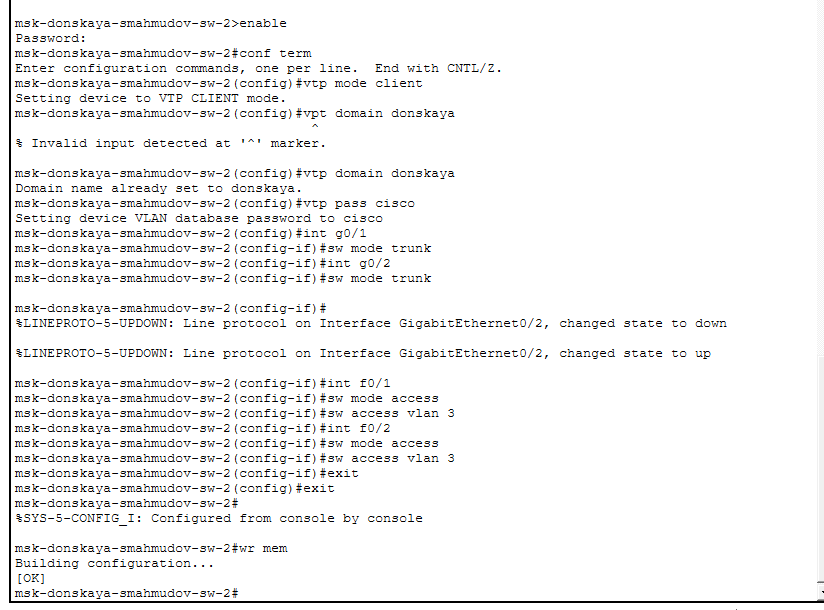

Настройка VTP-клиента и access-портов

## Настройка VTP Client на msk-donskaya-sw-3

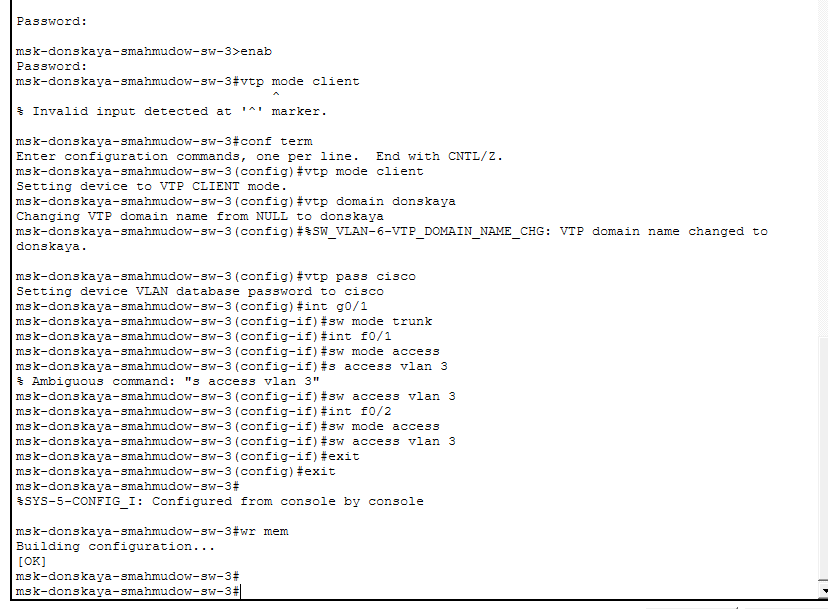

Настройка VTP-клиента на msk-donskaya-sw-3

## Настройка VLAN на msk-donskaya-sw-4

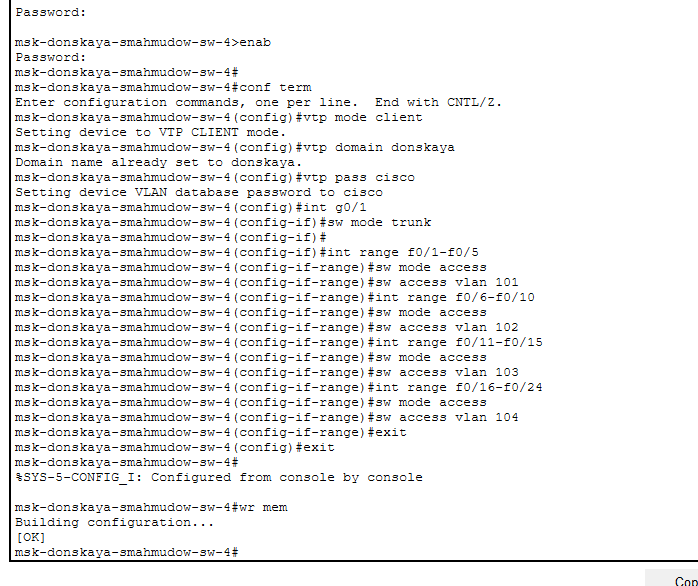

Настройка диапазонов портов и назначение VLAN

## Настройка msk-pavlovskaya-sw-1

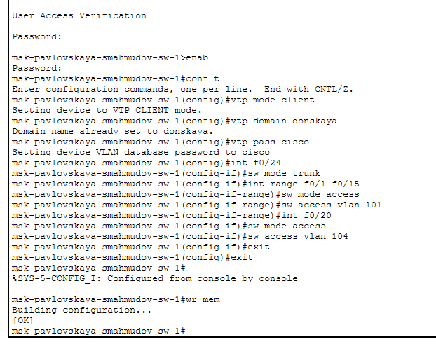

Настройка VTP-клиента и access-портов на msk-pavlovskaya-sw-1

## Настройка IP-адресов на серверах

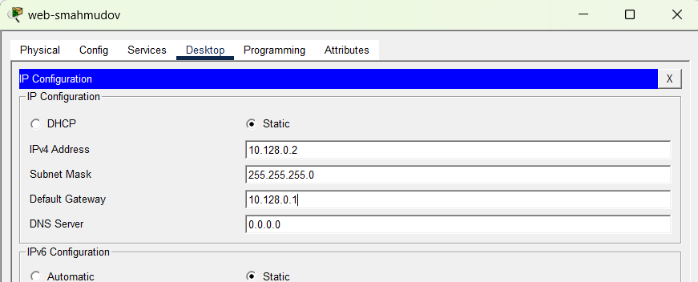

Настройка IP-адреса на сервере web-smahmudov

## Настройка IP-адресов на оконечных устройствах

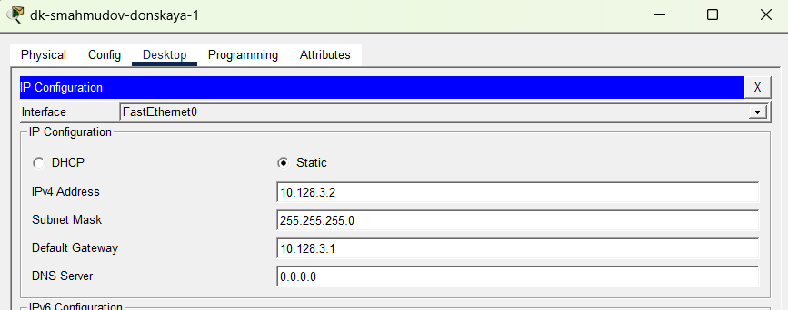

Настройка IP-адреса на узле dk-smahmudov-donskaya-1

## Проверка связи внутри одного VLAN

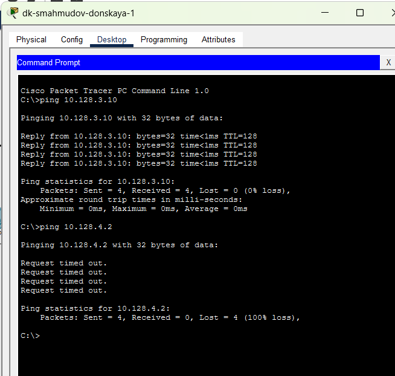

Проверка связи между устройствами одного VLAN

## Проверка недоступности разных VLAN

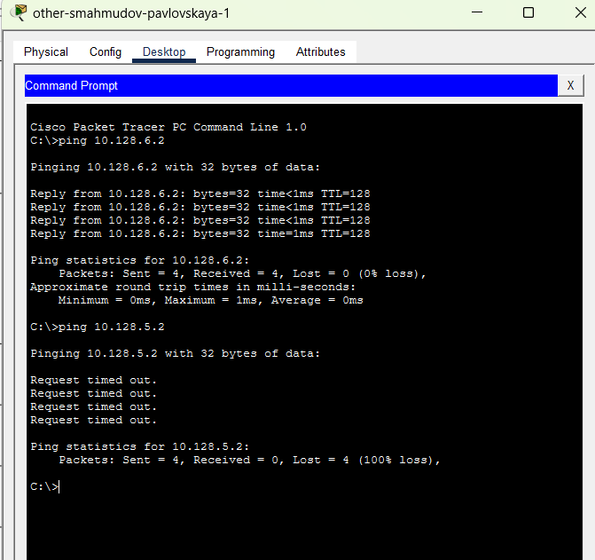

Проверка недоступности устройств из разных VLAN

## Топология сети в режиме Simulation

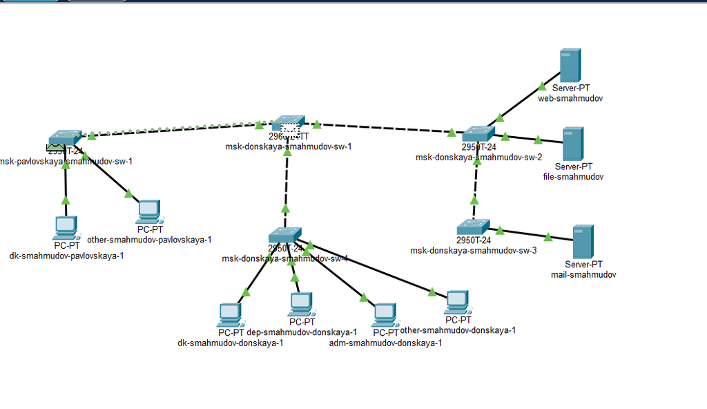

Топология сети и движение пакетов в режиме Simulation

## Анализ структуры пакета ICMP

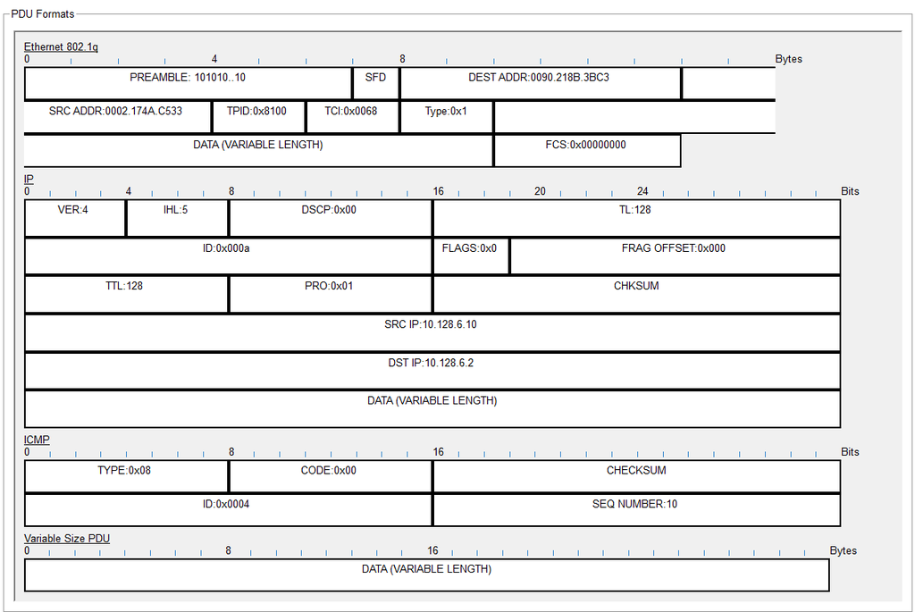

Анализ структуры передаваемого пакета ICMP

# Выводы по проделанной работе

## Вывод

- Изучены принципы сегментации локальной сети с использованием **VLAN**
- Освоена настройка **VTP Server** и **VTP Client**
- Настроены **Trunk**-соединения между коммутаторами
- Выполнено распределение портов по VLAN
- На серверах и ПК заданы статические IP-адреса и шлюзы
- Подтверждено, что:
  - устройства одного VLAN доступны друг другу
  - устройства разных VLAN без маршрутизации недоступны
- В режиме **Simulation** проанализирована передача **ICMP**-пакета и структура заголовков **Ethernet 802.1Q / IP / ICMP**